# Chapter 1: Hello Data

# Overview

- *1.1 Case study: Using stents to prevent strokes*
- *1.2 Data basics*
  - *1.2.1 Observations, variables, and data matrices*
  - *1.2.2 Types of variables*
  - 1.2.3 Relationships between variables
  - 1.2.4 Explanatory and response variables
  - 1.2.5 Observational studies and experiments

# 1.1 Case study: Using stents to prevent strokes

## Research Question

> Does the use of stents reduce the risk of stroke?
- **Treatment group**. Patients in the treatment group received a stent and medical management. The medical management included medications, management of risk factors, and help in lifestyle modification.
- **Control group**. Patients in the control group received the same medical management as the treatment group, but they did not receive stents.

Researchers *randomly assigned* 224 patients to the treatment group and 227 to the control group.

## Group activity

| group | 30 days_stroke | 30 days_no event | 365 days_stroke | 365 days_no event |
| --- | --- | --- | --- | --- |
| Control | 13 | 214 | 28 | 199 |
| Treatment | 33 | 191 | 45 | 179 |

1. Of the 224 patients in the treatment group, 45 had a stroke by the end of the first year. Using these two numbers, compute the proportion of patients in the treatment group who had a stroke by the end of their first year.
2. Compute the proportion of patients in the control group who had a stroke by the end of the first year.
3. What do these two *summary statistics* tell us about the *research question* “Does the use of stents reduce the risk of stroke?”

## Statistical investigations

Steps in a statistical investigation:

- Formulate a *research question*.
- Collect *data*.
- Summarize the data using *summary statistics*.
- *Interpret* the results in the context of the research question.

> Statistics is the study of how best to collect, analyze, and draw conclusions from data.

# 1.2 Data basics

## 1.2.1 Observations, variables, and data frames

- A *data frame* is a table (i.e., a spreadsheet).
  - Each row corresponds to an *observational unit*: the individual entities under consideration.
  - Each column corresponds to a *variable*: properties that can be observed on each observational unit.

| loan_amount | interest_rate | term | grade | state | total_income | homeownership |
| --- | --- | --- | --- | --- | --- | --- |
| 22000 | 10.90 | 60 | B | NJ | 59000 | rent |
| 6000 | 9.92 | 36 | B | CA | 60000 | rent |
| 25000 | 26.30 | 36 | E | SC | 75000 | mortgage |
| 6000 | 9.92 | 36 | B | CA | 75000 | rent |
| 25000 | 9.43 | 60 | B | OH | 254000 | mortgage |
| 6400 | 9.92 | 36 | B | IN | 67000 | mortgage |

## `county` Data Frame

- Observational units: United States counties
- Variables: name, state, pop2000, pop2010, pop2017, pop_change, poverty, homeownership, multi_unit, unemployment_rate, metro, median_edu, per_capita_income, median_hh_income, smoking_ban

| name | state | pop2000 | pop2010 | pop2017 | pop_change | poverty | homeownership | multi_unit | unemployment_rate | metro | median_edu | per_capita_income | median_hh_income | smoking_ban |
| --- | --- | --- | --- | --- | --- | --- | --- | --- | --- | --- | --- | --- | --- | --- |
| Autauga County | Alabama | 43671 | 54571 | 55504 | 1.48 | 13.7 | 77.5 | 7.2 | 3.86 | yes | some_college | 27841.70 | 55317 | none |
| Baldwin County | Alabama | 140415 | 182265 | 212628 | 9.19 | 11.8 | 76.7 | 22.6 | 3.99 | yes | some_college | 27779.85 | 52562 | none |
| Barbour County | Alabama | 29038 | 27457 | 25270 | -6.22 | 27.2 | 68.0 | 11.1 | 5.90 | no | hs_diploma | 17891.73 | 33368 | partial |
| Bibb County | Alabama | 20826 | 22915 | 22668 | 0.73 | 15.2 | 82.9 | 6.6 | 4.39 | yes | hs_diploma | 20572.05 | 43404 | none |
| Blount County | Alabama | 51024 | 57322 | 58013 | 0.68 | 15.6 | 82.0 | 3.7 | 4.02 | yes | hs_diploma | 21367.39 | 47412 | none |
| Bullock County | Alabama | 11714 | 10914 | 10309 | -2.28 | 28.5 | 76.9 | 9.9 | 4.93 | no | hs_diploma | 15444.16 | 29655 | none |
| Butler County | Alabama | 21399 | 20947 | 19825 | -2.69 | 24.4 | 69.0 | 13.7 | 5.49 | no | hs_diploma | 17014.95 | 36326 | NA |
| Calhoun County | Alabama | 112249 | 118572 | 114728 | -1.51 | 18.6 | 70.7 | 14.3 | 4.93 | yes | some_college | 23609.64 | 43686 | NA |
| Chambers County | Alabama | 36583 | 34215 | 33713 | -1.20 | 18.8 | 71.4 | 8.7 | 4.08 | no | hs_diploma | 21079.51 | 37342 | none |
| Cherokee County | Alabama | 23988 | 25989 | 25857 | -0.60 | 16.1 | 77.5 | 4.3 | 4.05 | no | hs_diploma | 23067.93 | 40041 | none |
| Chilton County | Alabama | 39593 | 43643 | 44067 | 0.97 | 19.4 | 75.1 | 4.4 | 4.05 | yes | hs_diploma | 22793.82 | 43501 | none |
| Choctaw County | Alabama | 15922 | 13859 | 12945 | -3.37 | 22.3 | 85.6 | 3.9 | 6.39 | no | hs_diploma | 20363.87 | 32122 | none |
| Clarke County | Alabama | 27867 | 25833 | 24083 | -4.12 | 25.3 | 80.0 | 6.3 | 8.48 | no | hs_diploma | 20099.21 | 33827 | none |
| Clay County | Alabama | 14254 | 13932 | 13367 | -0.29 | 19.1 | 72.8 | 11.2 | 4.37 | no | hs_diploma | 20879.67 | 37287 | none |
| Cleburne County | Alabama | 14123 | 14972 | 14900 | -0.51 | 19.1 | 74.9 | 5.3 | 4.46 | no | hs_diploma | 20158.98 | 37396 | none |
| Coffee County | Alabama | 43615 | 49948 | 51874 | 2.42 | 16.1 | 69.7 | 13.6 | 4.39 | no | some_college | 25627.63 | 49821 | none |
| Colbert County | Alabama | 54984 | 54428 | 54500 | -0.05 | 16.8 | 73.5 | 12.3 | 5.21 | yes | some_college | 22915.45 | 45477 | none |
| Conecuh County | Alabama | 14089 | 13228 | 12469 | -3.40 | 26.4 | 81.6 | 6.0 | 6.14 | no | hs_diploma | 14814.23 | 30434 | none |
| Coosa County | Alabama | 12202 | 11539 | 10754 | -4.43 | 14.4 | 83.7 | 1.9 | 4.62 | no | hs_diploma | 19147.01 | 34792 | none |
| Covington County | Alabama | 37631 | 37765 | 37092 | -1.90 | 17.6 | 74.0 | 6.1 | 5.24 | no | hs_diploma | 22146.06 | 39467 | none |
| Crenshaw County | Alabama | 13665 | 13906 | 13871 | 0.17 | 17.6 | 67.8 | 9.2 | 4.47 | no | hs_diploma | 20466.80 | 38937 | none |
| Cullman County | Alabama | 77483 | 80406 | 82755 | 2.58 | 16.4 | 74.7 | 8.5 | 3.71 | no | hs_diploma | 21287.64 | 40997 | none |
| Dale County | Alabama | 49129 | 50251 | 49226 | -1.07 | 19.6 | 61.2 | 13.2 | 4.43 | no | some_college | 22299.61 | 44711 | none |
| Dallas County | Alabama | 46365 | 43820 | 39215 | -6.59 | 31.9 | 62.6 | 16.0 | 7.53 | no | hs_diploma | 18042.21 | 30065 | none |
| DeKalb County | Alabama | 64452 | 71109 | 71617 | 1.00 | 21.5 | 77.5 | 6.4 | 4.49 | no | hs_diploma | 19007.97 | 38842 | none |
| Elmore County | Alabama | 65874 | 79303 | 81677 | 1.39 | 13.5 | 77.6 | 7.0 | 3.64 | yes | some_college | 27266.03 | 54981 | partial |
| Escambia County | Alabama | 38440 | 38319 | 37447 | -0.86 | 23.8 | 73.5 | 7.8 | 5.03 | no | hs_diploma | 18527.38 | 35026 | none |
| Etowah County | Alabama | 103459 | 104430 | 102755 | -1.07 | 17.9 | 73.0 | 11.9 | 4.57 | yes | some_college | 21208.43 | 42064 | none |
| Fayette County | Alabama | 18495 | 17241 | 16468 | -2.11 | 18.1 | 76.0 | 7.9 | 4.73 | no | hs_diploma | 21654.89 | 36541 | none |
| Franklin County | Alabama | 31223 | 31704 | 31495 | -0.03 | 23.0 | 69.2 | 10.4 | 4.23 | no | hs_diploma | 18783.03 | 39501 | partial |

[output cut: 70 more lines]

|  | variable | description |
| --- | --- | --- |
| 1 | name | Name of county. |
| 2 | state | Name of state. |
| 3 | pop2000 | Population in 2000. |
| 4 | pop2010 | Population in 2010. |
| 5 | pop2017 | Population in 2017. |
| 6 | pop_change | Population change from 2010 to 2017 (in percent). |
| 7 | poverty | Percent of population in poverty in 2017. |
| 8 | homeownership | Homeownership rate, 2006-2010. |
| 9 | multi_unit | Multi-unit rate: percent of housing units that are in multi-unit structures, 2006-2010. |
| 10 | unemployment_rate | Unemployment rate in 2017. |
| 11 | metro | Whether the county contains a metropolitan area, taking one of the values yes or no. |
| 12 | median_edu | Median education level (2013-2017), taking one of the values below_hs, hs_diploma, some_college, or bachelors. |
| 13 | per_capita_income | Per capita (per person) income (2013-2017). |
| 14 | median_hh_income | Median household income. |
| 15 | smoking_ban | Describes the type of county-level smoking ban in place in 2010, taking one of the values none, partial, or comprehensive. |

## 1.2.2 Types of variables

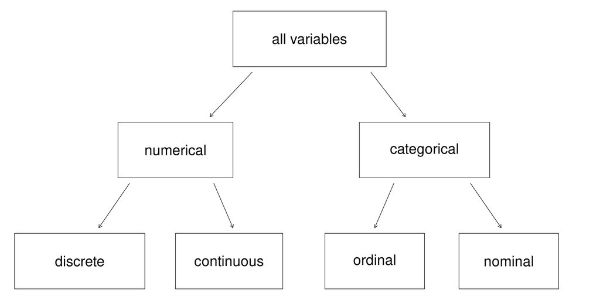

## Group Activity

1. Data were collected about students in a statistics course. Three variables were recorded for each student: number of siblings, student height, and whether the student had previously taken a statistics course. Classify each of the variables as continuous numerical, discrete numerical, or categorical.
2. An experiment is evaluating the effectiveness of a new drug in treating migraines. A `group` variable is used to indicate the experiment group for each patient: treatment or control. The `num_migraines` variable represents the number of migraines the patient experienced during a 3-month period. Classify each variable as either numerical or categorical.